# Analysis

## 1. Overview

Every payment transfer or claim has to pass this Y/N question: Is this Fraud?

## 1.1 Load Libraries

```python
import kagglehub
import os
import pandas as pd
import seaborn as sns
import numpy as np
import matplotlib.pyplot as plt
from sklearn.model_selection import train_test_split
from sklearn.preprocessing import RobustScaler
from sklearn.compose import ColumnTransformer
from sklearn.pipeline import Pipeline
from sklearn.linear_model import LogisticRegression
from sklearn.metrics import classification_report, roc_auc_score, confusion_matrix,  precision_recall_curve ,ConfusionMatrixDisplay, RocCurveDisplay, average_precision_score, PrecisionRecallDisplay
```

## 1.2 Load & Read Dataset

```python
# Download latest version
path = kagglehub.dataset_download("mlg-ulb/creditcardfraud")

print("Dataset downloaded and located.")

files = os.listdir(path)
for file in files:
    print(f'\nFile Name: {files}')

csv_file = [f for f in files if f.endswith('csv')][0] # Grab the 1st item in the list of all csv files found
file_path = os.path.join(path, csv_file)
```

```
Dataset downloaded and located.

File Name: ['creditcard.csv']
```

**Dataset overview:**

- Features `V1`, `V2`, … `V28` are numerical variables as a result of a PCA transformation to protect data privacy
- Feature `Time` contains the seconds elapsed between each transaction and the first transaction in the dataset.
- Feature `Amount` is the transaction Amount, this feature can be used for example-dependant cost-sensitive learning.
- Feature `Class` is the response variable:
  - `1` → Fraud Transaction
  - `0` → Non-Fraud Transaction

```python
# Read the data file
df = pd.read_csv(file_path)

print(df.head())
```

```
   Time        V1        V2        V3        V4        V5        V6        V7  \
0   0.0 -1.359807 -0.072781  2.536347  1.378155 -0.338321  0.462388  0.239599
1   0.0  1.191857  0.266151  0.166480  0.448154  0.060018 -0.082361 -0.078803
2   1.0 -1.358354 -1.340163  1.773209  0.379780 -0.503198  1.800499  0.791461
3   1.0 -0.966272 -0.185226  1.792993 -0.863291 -0.010309  1.247203  0.237609
4   2.0 -1.158233  0.877737  1.548718  0.403034 -0.407193  0.095921  0.592941

         V8        V9  ...       V21       V22       V23       V24       V25  \
0  0.098698  0.363787  ... -0.018307  0.277838 -0.110474  0.066928  0.128539
1  0.085102 -0.255425  ... -0.225775 -0.638672  0.101288 -0.339846  0.167170
2  0.247676 -1.514654  ...  0.247998  0.771679  0.909412 -0.689281 -0.327642
3  0.377436 -1.387024  ... -0.108300  0.005274 -0.190321 -1.175575  0.647376
4 -0.270533  0.817739  ... -0.009431  0.798278 -0.137458  0.141267 -0.206010

        V26       V27       V28  Amount  Class
0 -0.189115  0.133558 -0.021053  149.62      0
1  0.125895 -0.008983  0.014724    2.69      0
2 -0.139097 -0.055353 -0.059752  378.66      0
3 -0.221929  0.062723  0.061458  123.50      0
4  0.502292  0.219422  0.215153   69.99      0

[5 rows x 31 columns]
```

# 2. Exploratory Data Analysis

## 2.1 Data Structure

We want to have a quick overview as well as to double check the data structure such as:

- Number of rows
- Number of columns
- Data types
- Missing values
- Memory usage

```python
print(df.info())
```

```
<class 'pandas.DataFrame'>
RangeIndex: 284807 entries, 0 to 284806
Data columns (total 31 columns):
 #   Column  Non-Null Count   Dtype
---  ------  --------------   -----
 0   Time    284807 non-null  float64
 1   V1      284807 non-null  float64
 2   V2      284807 non-null  float64
 3   V3      284807 non-null  float64
 4   V4      284807 non-null  float64
 5   V5      284807 non-null  float64
 6   V6      284807 non-null  float64
 7   V7      284807 non-null  float64
 8   V8      284807 non-null  float64
 9   V9      284807 non-null  float64
```

[output cut: 24 more lines]

## 2.2 Data Cleaning

### 2.2.1 Missing Values Analysis

Missing values can affect the performance of machine learning models:

- **Algorithmic crashes:** if the models in learning libraries (i.e Scikit-Learn's Logistic Regression) do not handle missing values, the training process will crash.
- **Hidden Bias:** if the missing values are not handled properly, the model may learn patterns that are not representative of the real-world data, leading to biased predictions.

```python
missing_val_counts = df.isnull().sum()
print(missing_val_counts[missing_val_counts>0].index.to_list())
```

```
[]
```

The dataset contains no missing values.

- **No imputation is required**
- The dataset is ready for further preprocessing and analysis.

### 2.2.2 Duplicate records analysis

Duplicate transactions could skew the model performance by causing certain patterns to be overrepresented in the training process. So if there are any duplicated rows presented, they will be removed

- **Reduce bias:** as if a specific fraudulent transaction is duplicated 10 times, the model will see that exact pattern repeatedly
- **Improve model generalisation** (the ability of your model to perform well on new, unseen data): as the model might just memorise the rows
- **Prevent information leakage:** if we split your data into a training set and a testing set without removing duplicates first, the same row might exist in both sets.

```python
duplicated_rows = df.duplicated().sum()
print(f'Number of duplicated rows: {duplicated_rows}')

df = df.drop_duplicates()
df.shape
```

```
Number of duplicated rows: 1081
```

```
(283726, 31)
```

### 2.2.3 Class Distribution Analysis

Fraud detection is an imbalanced classification problem as most transactions are legitimate, while only a very small fraction are fraudulent.

Therefore, we need to examine the class distribution to understand:

- Severity of imbalance
- Need for resampling techniques
- Expected modeling challenges

```python
print(df['Class'].value_counts(normalize=False))
```

```
Class
0    283253
1       473
Name: count, dtype: int64
```

```python
print(df['Class'].value_counts(normalize=True))
```

```
Class
0    0.998333
1    0.001667
Name: proportion, dtype: float64
```

As it is said, the dataset is highly unbalanced/low prevalence, the positive class (frauds) account only for 0.167% of all transactions (after removing duplicates).

The greater the imbalance, the more challenging it becomes for machine learning models to correctly identify fraudulent cases.

Given the class imbalance ratio, confusion matrix accuracy is not meaningful for unbalanced classification because if a model predicts non-fraud for all transaction, it will achieve an accuracy of 99.8% as fraudulent transactions represents less than 0.2% of the total in our dataset.

$$\text{Accuracy} = \frac{\text{True Positives} + \text{True Negatives}}{\text{Total Predictions}}$$

So we need metrics that focus on the minority class such as:

- **Precision:** $$\text{Precision} = \frac{\text{TP}}{\text{TP + FP}}$$ → Of all transactions predicted as fraud, how many were actually fraudulent?
- **Recall:** $$\text{Recall} = \frac{\text{TP}}{\text{TP + FN}}$$ → Of all actual fraud cases, how many did we correctly identify?
- **F1 Score:** $$\text{F1 Score} = 2 \times \frac{\text{Precision} \times \text{Recall}}{\text{Precision} + \text{Recall}}$$ → The combined metric of both Precision and Recall that penalises extreme values
- **ROC-AUC** (Receiver Operating Characteristic - Area Under Curve): plots the True Positive Rate (Recall) against the False Positive Rate ($FPR = \frac{FP}{FP + TN}$) at various threshold settings
- **PR-AUC** (Precision-Recall Area Under Curve): plots Precision vs Recall at various threshold settings.

## 2.3 Data Exploration

- Multicollinearity can make it hard for the model to determine which feature is actually responsible for the prediction. Therefore, we perform a correlation analysis below:

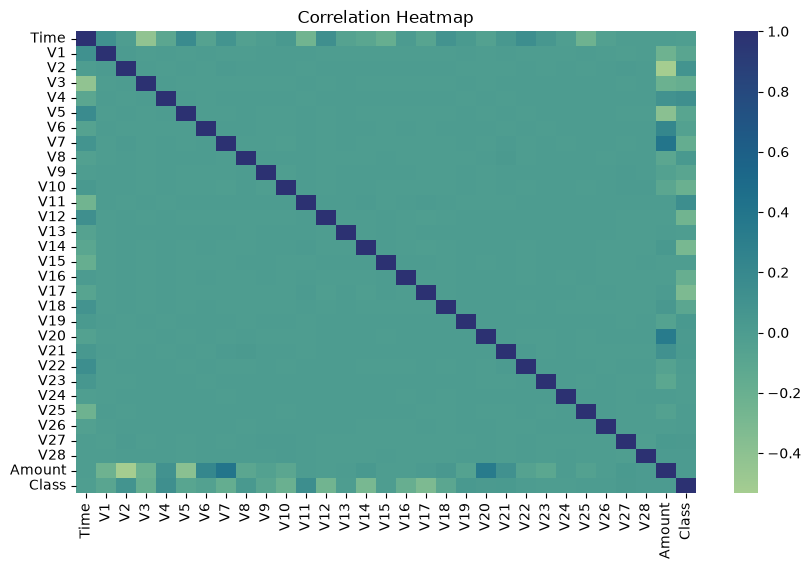

```python
plt.figure(figsize=(10, 6))
sns.heatmap(df.corr(), cmap='crest', annot=False)
plt.title("Correlation Heatmap")
plt.show()
```

The correlation heatmap shows that deep dark blue represents strong linear correlation between variables, while teal/green colors represents weak linear correlation.

Here, we dont see much deep blue blocks outside the diagonal, so there are no signs of multicollinearity.

=> We can keep all features.

However, most of the `V` features also appear to have very weak correlations with `Class` (response variable), which means the fraud signals are likely to be non-linear and cannot be captured by this simple correlation heatmap.

=> We should also test different models that are able to capture non-linear relationships like Random Forests, XGBoost, etc.

We also plot the correlation between the features and the response variable `Class` to see which features are more correlated with the target variable.

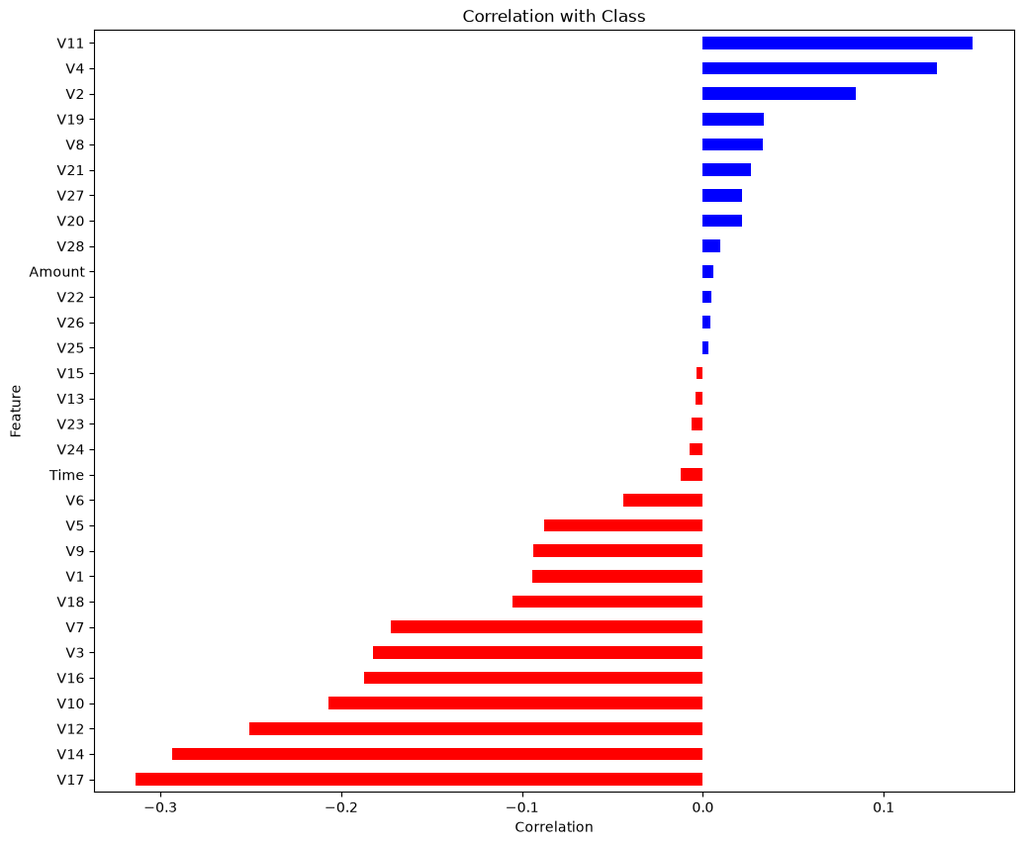

```python
corr_with_class = df.corr()['Class'].drop('Class').sort_values(ascending = True)
corr_with_class.plot(kind = 'barh', figsize = (12,10), color = ['red' if coef < 0 else 'blue' for coef in corr_with_class])
plt.title('Correlation with Class')
plt.xlabel('Correlation')
plt.ylabel('Feature')
plt.show()
```

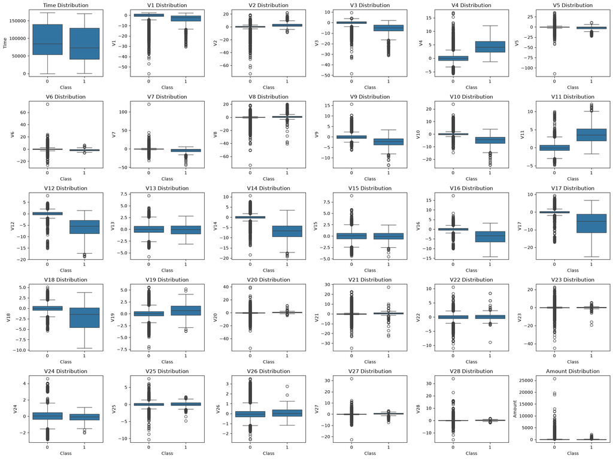

```python
features = [cols for cols in df.columns if cols != 'Class']

fig, axes = plt.subplots(5, 6, figsize=(20, 15))
axes = axes.flatten() # To flat out  axes[0,0] to axes[4,5] (5x6 grid) to axes[0] to axes[29]

for i, feature in enumerate(features):
    sns.boxplot(x='Class', y = feature, data = df, ax= axes[i], showfliers=True)
    axes[i].set_title(f'{feature} Distribution')

plt.tight_layout()
plt.show()
```

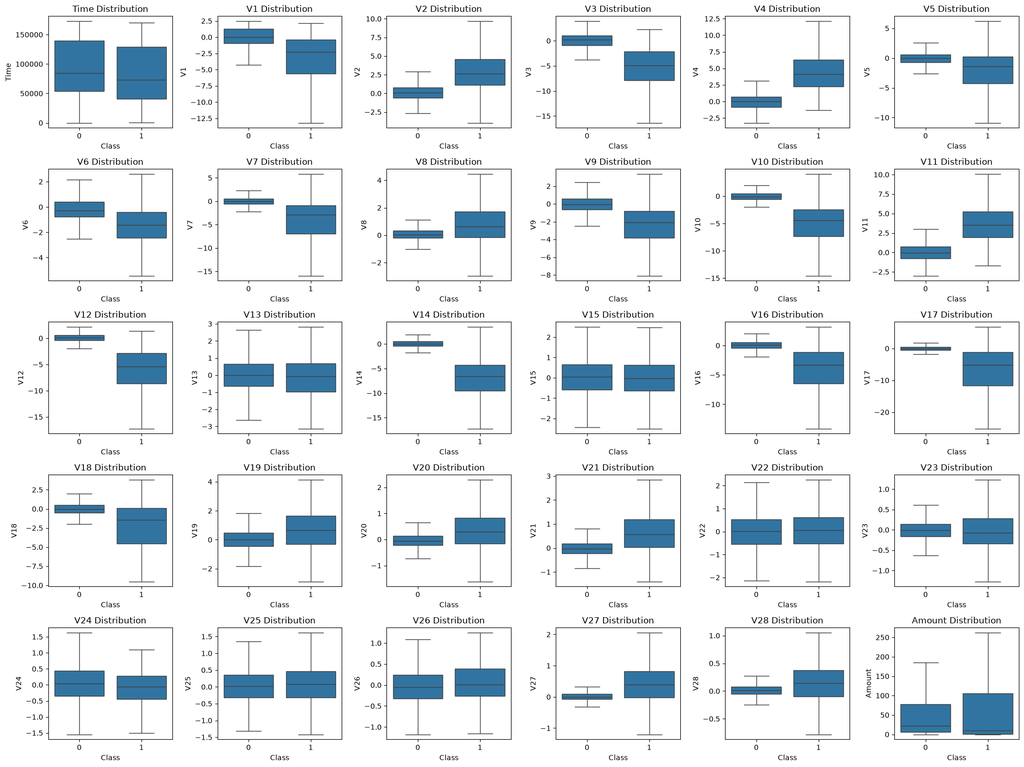

```python
fig, axes = plt.subplots(5, 6, figsize=(20, 15))
axes = axes.flatten() # To flat out  axes[0,0] to axes[4,5] (5x6 grid) to axes[0] to axes[29]

for i, feature in enumerate(features):
    sns.boxplot(x='Class', y = feature, data = df, ax= axes[i], showfliers=False)
    axes[i].set_title(f'{feature} Distribution')

plt.tight_layout()
plt.show()
```

- **Strong separators:** `V14`, `V12`, `V10`, `V17`, `V4`, `V11`, `V3`, `V16` show visibly different medians and spreads between the two classes (e.g. `V14` sits near 0 for legitimate transactions but drops to roughly -7 for fraud). These are the features most likely to carry real predictive weight, and a natural set to watch closely in later feature-importance results.
- **Weak separators:** `V13`, `V15`, `V22`, `V23`, `V24`, `V25`, `V26` show near-identical boxes for both classes. There features show little to no discriminating power on their own.
- **`Time`** overlaps heavily between classes, which means transaction timing alone doesn't strongly indicate fraud in this dataset.
- **`Amount`** is actually *lower* on average for fraud than for legitimate transactions. This is worth noting since it runs counter to the common assumption that fraud means unusually large purchases.

This is a useful sanity check to carry into modeling, especially when a trained model's feature importances don't roughly agree with this list (e.g. if `V13`/`V15`/`V22`-`V26` show up as highly important), then that's worth a second look, because it could mean the model is picking up an interaction/non-linear effect these single-feature boxplots can't show, or it could be a sign of an issue like leakage or overfitting.

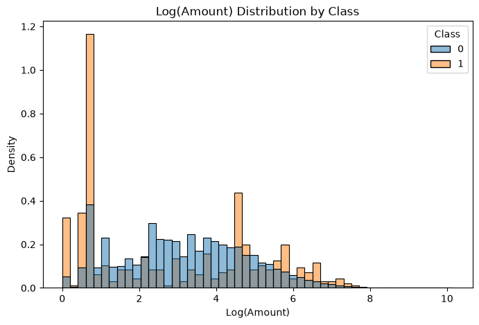

```python
df['log_amount'] = np.log1p(df['Amount']) # log1p means log(amount + 1) as log(0) = undefined so log(1+0) = 0 for transactions with amount equals 0

plt.figure(figsize=(8,5))
sns.histplot(data=df, x='log_amount', hue='Class', bins=50, stat='density', common_norm=False, alpha=0.5)
plt.title('Log(Amount) Distribution by Class')
plt.xlabel('Log(Amount)')
plt.show()
```

Fraud (orange) is sharply concentrated in two narrow spike:

Legitimate transactions (blue) are much more spread out and distributed fairly evenly across the whole range from log_amount ≈ 0 up through ≈ 6-7 (roughly $1 to over $1000).

=> Fraudulent transactions in this dataset aren't randomly sized like legitimate ones, they cluster heavily around a couple of specific amount levels, especially very small amounts (~$1). This is might be a fraud pattern that fraudsters first test a stolen card with a tiny charge (like $1) before attempting larger charges, to check if the card is still active/valid without triggering suspicion. The secondary spike around $90-150 could reflect a common "safe" charge amount fraudsters use once a card is validated.

# 3. Feature and Target Variable Preparation

From previous EDA, we conclude to keep all features, so for our machine learning model, we will assign the variables as below:

- **Features** (`Time`, `Amount`, `V1` .. `V28`, `log_amount`) → `X`
- **Target Variable** (0: Non-fraud, 1: Fraud) → `y`

=> Here, as all features are numerical values, we dont have to separate numericals and categorical features.

```python
X = df.drop("Class", axis=1)

y = df["Class"]

print(f"{X.shape[1]} Features:"
      f" \n  {X.columns.tolist()}")

print(f"\n1 Target : {y.name}")
```

```
31 Features:
  ['Time', 'V1', 'V2', 'V3', 'V4', 'V5', 'V6', 'V7', 'V8', 'V9', 'V10', 'V11', 'V12', 'V13', 'V14', 'V15', 'V16', 'V17', 'V18', 'V19', 'V20', 'V21', 'V22', 'V23', 'V24', 'V25', 'V26', 'V27', 'V28', 'Amount', 'log_amount']

1 Target : Class
```

# 4. Train-Test Split

We will divide the dataset into:

- **Training set:** for the model to learn patterns of transactions from historical data
- **Testing set:** to evaluate the model performance on unseen data if the model is able to capture the patterns successfully
- In this case, we wont split further into validation set even the data is large enough (>200,000 records) because the proportion of fraud cases in our data is super tiny. Further splitting might make the model harder to capture the patterns of fraudulent.
- We will perform a stratified split as it is able to preserve the original class distribution in both datasets, i.e it forces the percentage of fraud to be the same in both training set and test set.

> **P/s:** If we are going to use a validation set, it is better to split into training and validation sets before data exploration. If we are using cross validation this is not necessary.

```python
X_train, X_test, y_train, y_test = train_test_split(
    X,
    y,
    test_size=0.20, # 20% of the data is for testing, 80% for training
    random_state=42,
    stratify=y # strify on y
)

print("Training Set :", X_train.shape)
print("Testing Set :", X_test.shape)
```

```
Training Set : (226980, 31)
Testing Set : (56746, 31)
```

**Checking Fraud Distribution After Splitting:** to make sure both training and testing set has a similar fraud distribution to ensure model evaluation unbiased.

```python
train_fraud_rate = y_train.value_counts(normalize= True)*100
test_fraud_rate = y_test.value_counts(normalize= True)*100

print(f'Fraud Rate in Training Set: {train_fraud_rate[1]:.6f} %')
print(f'Fraud Rate in Testing Set: {test_fraud_rate[1]:.6f} %')
```

```
Fraud Rate in Training Set: 0.166534 %
Fraud Rate in Testing Set: 0.167413 %
```

# 5. Feature Scaling

Only `Time` and `Amount` feature need scaling here, as `V1`-`V28` features are already PCA-transformed. There are four common feature scaling options:

### 1. StandardScaler (Z-Score Normalization)

Rescales to mean 0, standard deviation 1. Assumes roughly normal data.

$$x_{scaled} = \frac{x - \mu}{\sigma}$$

**Example:** average height 170cm, std 10cm -> a height of 180cm becomes `1.0`, 160cm becomes `-1.0`.

**Use when:** the default choice for most algorithms, especially the distance-based ones (KNN, SVM, PCA) or those assuming normally distributed data (Linear/Logistic Regression).

### 2. MinMaxScaler (Normalization)

Compresses everything into a fixed range, usually `[0, 1]`. Preserves the original distribution's shape but strictly bounds the extremes.

$$x_{scaled} = \frac{x - x_{min}}{x_{max} - x_{min}}$$

**Example:** pixel brightness 0-255 -> a value of 127.5 becomes exactly `0.5`.

**Use when:** the data has known, strict bounds, isn't normally distributed, or the algorithm needs positive-only inputs (e.g. image processing, Naive Bayes). **Highly sensitive to outliers.**

### 3. RobustScaler

Ignores the mean and extremes. Centers on the **median**, scales by the **IQR** (middle 50% of the data).

$$x_{scaled} = \frac{x - \text{median}}{\text{IQR}}$$

**Example:** an income dataset with a billionaire -> the mean gets dragged upward by that one value, but RobustScaler ignores it entirely, scaling based only on the middle class's spread. The billionaire's scaled value just becomes a large number, without distorting everyone else's scale.

**Use when:** the data has significant outliers you can't (or shouldn't) delete, but you don't want them compressing the scale for everything else.

### 4. MaxAbsScaler

Scales by the absolute maximum value, shifting everything into `[-1, 1]` **without** moving the center (a zero stays exactly zero).

$$x_{scaled} = \frac{x}{\max(|x|)}$$

**Example:** values ranging -50 to 100 -> max absolute value is 100 -> -50 becomes `-0.5`, 100 becomes `1.0`.

**Use when:** working with sparse data (mostly zeros, e.g. TF-IDF text features). As it doesn't shift the mean, it won't turn millions of meaningful zeros into non-zero decimals.

In this case, `Amount` is heavily right-skewed with real outliers, which is confirmed in Section 2.3's EDA, where the log-transformed distribution showed fraud clustering sharply around specific values (~$1, ~$90-150) against a much broader, multi-modal spread for legitimate transactions, and the raw boxplots showed `Amount` dominated by a long tail of large values. `Time` is less dramatically skewed but it is not close to normally distributed neither, which rules out `StandardScaler` as the natural choice.

Between the two outlier-tolerant options, `RobustScaler` fits better than `MinMaxScaler` here because `MinMaxScaler` is *highly sensitive to outliers* (a single extreme `Amount` value would stretch the entire scale), compressing the vast majority of (normal-range) transactions into a tiny sliver near 0. `RobustScaler`'s median/IQR centering means the handful of very large transactions don't distort how every other transaction gets scaled, exactly the property needed when outliers are expected and meaningful (as they are in fraud data), not something to be engineered away.

```python
numeric_features = ['Time','Amount']
preprocessor = ColumnTransformer(
    transformers = [
        (
        'num',
        RobustScaler(),
        numeric_features
        )
    ],
    remainder= 'passthrough'
    )
```

# 6. Model Selection

- We will test different models to find the best one for our dataset. The models we will test include:
  - Logistic Regression
  - Random Forest Classifier
  - XGBoost Classifier

## 6.1 Logistic Regression

- Logistic Regression is one of the most widely used algorithms for binary classification. Because fraud detection is a binary classification problem, Logistic Regression serves as an excellent starting point for performance comparison.

**Advantages:**

- Fast training
- Interpretable coefficients
- Strong baseline model
- Produces probability estimates

**SMOTE (Synthetic Minority Over-sampling Technique):** is a popular technique for handling imbalanced datasets, especially in classification problems like fraud detection. It works by generating synthetic samples of the minority class (in this case, fraudulent transactions) to balance the class distribution.

- Reduce class imbalance, which can help improve model performance and reduce bias towards the majority class.
- Improve minority class learning
- Improve Precision, Recall, and F1 Score by providing the model with more examples of the minority class to learn from.

```python
from imblearn.pipeline import Pipeline as ImbPipeline
from imblearn.over_sampling import SMOTE

lr_pipeline = ImbPipeline([
    (
        'preprocessor',
        preprocessor
    ),
    (
        'smote',
        SMOTE(random_state=42)

    ),
    (
        'model',
        LogisticRegression(
            random_state= 42,
            max_iter= 1000
        )
    )
])
```

```python
lr_pipeline
```

```
Pipeline(steps=[('preprocessor',
                 ColumnTransformer(remainder='passthrough',
                                   transformers=[('num', RobustScaler(),
                                                  ['Time', 'Amount'])])),
                ('smote', SMOTE(random_state=42)),
                ('model', LogisticRegression(max_iter=1000, random_state=42))])
```

### 6.1.1 Training Logistic Regression Model

The model is trained on the original (imbalanced) training split. SMOTE is applied inside the pipeline during `.fit()`, so oversampling only ever happens on the training data, never on the test set.

The objective is to learn patterns that distinguish fraudulent transactions from legitimate transactions, and to prevent data leakage in cross-validation in the later stages.

```python
lr_pipeline.fit(
    X_train,
    y_train
)
```

```
Pipeline(steps=[('preprocessor',
                 ColumnTransformer(remainder='passthrough',
                                   transformers=[('num', RobustScaler(),
                                                  ['Time', 'Amount'])])),
                ('smote', SMOTE(random_state=42)),
                ('model', LogisticRegression(max_iter=1000, random_state=42))])
```

```python
lr_pred = lr_pipeline.predict(X_test)

lr_prob = lr_pipeline.predict_proba(X_test)[:,1]
```

### 6.1.2 Model Evaluation Metrics

The following metrics are used:

- Precision
- Recall
- F1 Score
- ROC-AUC
- PR-AUC

These metrics provide a more reliable evaluation than accuracy for highly imbalanced datasets.

```python
print(classification_report(y_test, lr_pred))
```

```
              precision    recall  f1-score   support

           0       1.00      0.97      0.99     56651
           1       0.05      0.87      0.10        95

    accuracy                           0.97     56746
   macro avg       0.53      0.92      0.54     56746
weighted avg       1.00      0.97      0.99     56746
```

#### Confusion Matrix

The confusion matrix reveals how effectively the model distinguishes fraudulent transactions from legitimate ones.

- **True Positives:** means high successful number of frauds detected.
- **False Negatives:** represent missed fraud cases (Actual frauds but predicted as non-fraud).
- **False Positives:** represent false fraud alert (Legitimate transactions but predicted as fraud).

Depends on the system, there will be different priorities, either to minimize False Negatives or False Positives or maximize overall accuracy. So depending on the priority, we will need to adjust the threshold for classification accordingly. But in this fraud detection system, a large number of False Negatives will decrease customer satisfaction and trust in the system, while a large number of False Positives will increase business cost to double check whether the transaction is real fraud. Therefore, we want to balance both False Negatives and False Positives, by focusing on optimizing the F1 Score to ensure a balanced approach to fraud detection.

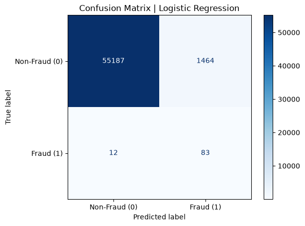

```python
lr_cm = confusion_matrix(y_test, lr_pred)
lr_cm_disp = ConfusionMatrixDisplay(confusion_matrix= lr_cm, display_labels= ['Non-Fraud (0)', 'Fraud (1)'])
lr_cm_disp.plot(cmap = 'Blues')
plt.title('Confusion Matrix | Logistic Regression')
plt.show()
```

#### ROC Curve Analysis

The Receiver Operating Characteristic (ROC) Curve evaluates model performance across multiple classification thresholds.

ROC-AUC measures the model's ability to separate fraud and non-fraud transactions.

**Interpretation:**

| ROC-AUC | Meaning |
| --- | --- |
| 0.50 | Random Guessing |
| 0.70 | Acceptable |
| 0.80 | Good |
| 0.90+ | Excellent |

```python
lr_roc_auc = roc_auc_score(y_test, lr_prob)
lr_roc_auc
```

```
0.9571427642379147
```

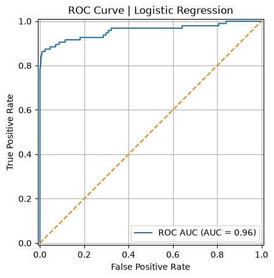

```python
RocCurveDisplay.from_estimator(estimator=lr_pipeline, X = X_test, y = y_test, name = 'ROC AUC')
plt.plot([0,1],[0,1],"--")
plt.grid()
plt.xlabel('False Positive Rate')
plt.ylabel('True Positive Rate')
plt.title('ROC Curve | Logistic Regression')
plt.show()
```

#### Precision Recall Curve Analysis

For highly imbalanced datasets, Precision-Recall curves are often more informative than ROC curves because True Negatives, which dominate the dataset, can inflate False Positive Rate (FPR) and make the ROC curve appear more favorable than it actually is.

```python
lr_pr_auc= average_precision_score(y_test, lr_prob)
lr_pr_auc
```

```
0.68157607063583
```

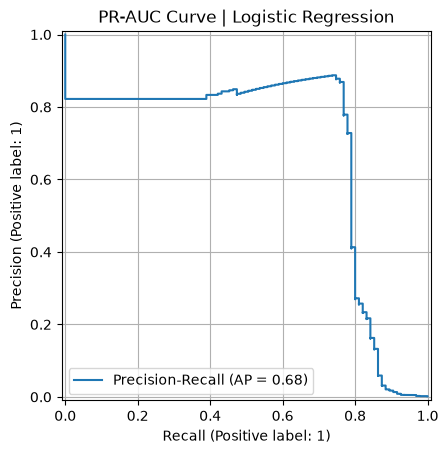

```python
PrecisionRecallDisplay.from_estimator(estimator= lr_pipeline, X = X_test, y = y_test, name = 'Precision-Recall')
plt.title('PR-AUC Curve | Logistic Regression')
plt.grid()
plt.show()
```

### 6.1.3 Cross-Validated Threshold Selection

Classification models output probabilities rather than direct class predictions.

By default, a threshold of 0.50 is used:

- Probability > 0.50 → Fraud
- Probability ≤ 0.50 → Non-Fraud

However, for imbalanced datasets this threshold is often suboptimal.

=> Threshold optimization helps identify the threshold that maximizes model performance, particularly the F1 Score.

To avoid data leakage, threshold optimization should be performed on the validation set or using cross-validation, not on the test set.

=> We use stratified k-fold cross-validation to find the optimal threshold for our model. This approach ensures that each fold maintains the original class distribution, providing a more reliable estimate of model performance across different thresholds.

```python
from sklearn.model_selection import StratifiedKFold, cross_val_predict

skf = StratifiedKFold(n_splits = 5, shuffle=True, random_state=42)

y_train_prob = cross_val_predict(
    estimator= lr_pipeline,
    X = X_train,
    y = y_train,
    cv = skf,
    method = 'predict_proba'
    )[:,1]

precision, recall, thresholds = precision_recall_curve(y_train, y_train_prob)

# Calculate f1-score for each threshold (add a tiny number of 1e-10 to prevent dividing by 0)
f1_scores = 2*(precision*recall)/(precision + recall + 1e-10)

precision, recall, thresholds, f1_scores
```

```
(array([0.00166534, 0.00166535, 0.00166536, ..., 0.87128713, 0.86734694,
        1.        ], shape=(226775,)),
 array([1.        , 1.        , 1.        , ..., 0.46560847, 0.44973545,
        0.        ], shape=(226775,)),
 array([2.90225732e-40, 5.40338812e-38, 1.37318181e-34, ...,
        1.00000000e+00, 1.00000000e+00, 1.00000000e+00], shape=(226774,)),
 array([0.00332515, 0.00332517, 0.00332518, ..., 0.60689655, 0.59233449,
        0.        ], shape=(226775,)))
```

```python
thresholds_df = pd.DataFrame({
    'threshold': thresholds,
    'precision' : precision[:-1],
    'recall' : recall[:-1],
    'f1_score': f1_scores[:-1]
    })

optimal_threshold = thresholds_df.loc[thresholds_df['f1_score'].idxmax(),'threshold']
optimal_threshold
```

```
np.float64(0.999999962418972)
```

### 6.1.4 Test Evaluation for Tuned Threshold

After determining the optimal threshold through cross-validation, we evaluate the model on the test set using this tuned threshold. This final evaluation provides an unbiased assessment of the model's performance on unseen data, ensuring that the results reflect its true predictive capabilities in real-world scenarios.

```
              precision    recall  f1-score   support

           0       1.00      1.00      1.00     56651
           1       0.89      0.75      0.81        95

    accuracy                           1.00     56746
   macro avg       0.94      0.87      0.91     56746
weighted avg       1.00      1.00      1.00     56746
```

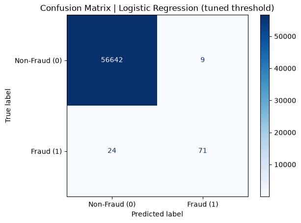

```python
lr_pred_tuned = (lr_prob >= optimal_threshold).astype(int)

print(classification_report(y_test, lr_pred_tuned))
cm_tuned = confusion_matrix(y_test, lr_pred_tuned)
ConfusionMatrixDisplay(confusion_matrix=cm_tuned, display_labels=['Non-Fraud (0)', 'Fraud (1)']).plot(cmap='Blues')
plt.title('Confusion Matrix | Logistic Regression (tuned threshold)')
plt.show()
```

**Findings:**

[output not shown]

**Why the default threshold performed so poorly — most likely a consequence of SMOTE:** training on a perfectly 50/50 SMOTE-balanced dataset shifts the model's whole notion of "confident." A raw 0.5 cutoff, calibrated for a balanced training distribution, is far too permissive once applied to real-world data that's actually ~99.8% legitimate. This is exactly why threshold tuning isn't just helpful but *necessary* after using SMOTE for an imbalanced problem like this one.

**Note on AUC metrics:** ROC-AUC (0.957) and PR-AUC (0.682), computed earlier, are threshold-independent and therefore unaffected by this tuning step — they summarize the model's ranking quality across every possible threshold. Only the classification report / confusion matrix numbers shift with the chosen threshold, since those depend on where exactly the cutoff is drawn.

We assume it takes roughly 1 hour to review a transaction manually to double check if it is a real fraud and assume the average salary for per hour is $12, then we set `review_cost = 12`

However, **this assumption matters a lot** the "optimal" thresholds and the entire cost-vs-benefit conclusion below are sensitive to this number. A materially different review cost (e.g. $5 vs $12) can shift which thresholds come out best, and by how much the bucket-based approach outperforms a single global threshold. Any real deployment should replace this with an actual estimated cost from the business (analyst time, tooling, etc.) before trusting the conclusion.

**For Missed Fraud (fn_mask)**

When a fraudster succeeds, the bank loses the actual stolen money. Missing a $5,000 fraud hurts the business vastly more than missing a $5 fraud. Therefore, treating every mistake as equal is financially dangerous.

**For False Alarms (fp_mask)**

When the model flags a legitimate customer, the bank does not lose the transaction amount. It only loses the administrative cost of paying an employee to review the alert (e.g., $12). Reviewing a $5,000 false alarm takes the exact same amount of time as reviewing a $5 false alarm. Here, we do not care about the transaction size, but only care about how many false alarms occurred.

```python
def total_cost( y_test, y_pred, amounts, review_cost = 12):
    fn_mask = (y_pred == 0) & (y_test == 1) # missed fraud
    fp_mask = (y_pred == 1) & (y_test == 0) # false alarm

    missed_fraud_cost = amounts[fn_mask].sum()
    false_alarm_cost = fp_mask.sum() * review_cost

    return missed_fraud_cost + false_alarm_cost
```

```python
from itertools import product

amounts = X_train['Amount'].values # .values to return np array, else return pd series

best_cost = float('inf')
best_thres_combi = None

for thres_low, thres_mid, thres_high in product(
    np.arange(0.9, 1.0, 0.01),
    np.arange(0.8, 1.0, 0.01),
    np.arange(0.6, 1.0, 0.01)
):
    conditions = [
        amounts < 50,
        (amounts >= 50) & (amounts <1000),
        amounts >= 1000
    ]

    applied_threshold = np.select(condlist = conditions, choicelist= [thres_low, thres_mid, thres_high], default  = 0.99)
    y_preds = (y_train_prob >= applied_threshold).astype(int)
    cost = total_cost(y_train.values, y_preds, amounts, review_cost= 12)

    if cost < best_cost:
        best_cost = cost
        best_thres_combi = (thres_low, thres_mid, thres_high)


print("Best thresholds (low, mid, high):", best_thres_combi)
print("Lowest total cost found:", best_cost)
```

```
Best thresholds (low, mid, high): (np.float64(0.9900000000000001), np.float64(0.9700000000000002), np.float64(0.9900000000000003))
Lowest total cost found: 13474.21
```

```
              precision    recall  f1-score   support

           0       1.00      1.00      1.00     56651
           1       0.55      0.79      0.65        95

    accuracy                           1.00     56746
   macro avg       0.78      0.89      0.82     56746
weighted avg       1.00      1.00      1.00     56746
```

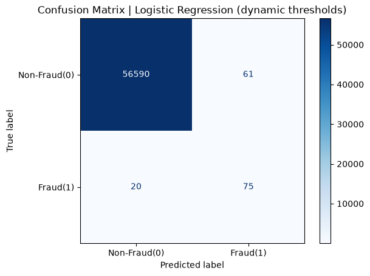

```
Estimated total cost on test set: 4521.34
```

```python
best_low, best_mid, best_high = best_thres_combi

def dynamic_threshold(lr_prob, amount):
    conditions = [amount < 50, (amount >= 50)&(amount < 1000), amount >= 1000]
    applied_threshold = np.select(conditions, best_thres_combi, default = 0.99)
    return (lr_prob >= applied_threshold).astype(int)

y_pred_final = dynamic_threshold(lr_prob, X_test['Amount'].values)   # update dynamic_threshold to use best_combo values

print(classification_report(y_test, y_pred_final))
cm = ConfusionMatrixDisplay(confusion_matrix(y_test, y_pred_final), display_labels = ['Non-Fraud(0)', 'Fraud(1)'])
cm.plot(cmap = 'Blues')
plt.title('Confusion Matrix | Logistic Regression (dynamic thresholds)')
plt.show()

final_test_cost = total_cost(y_test.values, y_pred_final, X_test['Amount'].values, review_cost=12)
print("Estimated total cost on test set:", final_test_cost)
```

```python
single_threshold_cost = total_cost(y_test.values, lr_pred_tuned, X_test['Amount'].values, review_cost= 12)
print("Single global threshold cost:", single_threshold_cost)
```

```
Single global threshold cost: 3920.2799999999997
```

### 6.1.5 Feature Importance Analysis

```
                  feature  coefficient
5           remainder__V4     0.901430
2           remainder__V1     0.745829
6           remainder__V5     0.722421
12         remainder__V11     0.688688
23         remainder__V22     0.688451
29         remainder__V28     0.590294
24         remainder__V23     0.579493
20         remainder__V19     0.462433
1             num__Amount     0.439756
3           remainder__V2     0.417625
25         remainder__V24     0.345544
4           remainder__V3     0.314512
22         remainder__V21     0.187544
30  remainder__log_amount     0.185134
```

[output cut: 17 more lines]

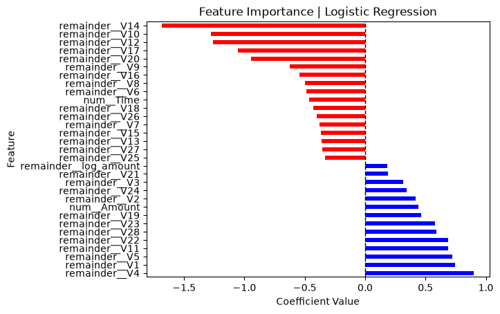

```python
lr_preprocessor = lr_pipeline.named_steps['preprocessor']
lr_model = lr_pipeline.named_steps['model']

lr_features = lr_preprocessor.get_feature_names_out()

lr_coef = lr_model.coef_[0]

lr_coef_df = pd.DataFrame({
    'feature': lr_features,
    'coefficient': lr_coef
}).sort_values(by = 'coefficient', ascending = False)

print(lr_coef_df)
lr_coef_df.plot(
    kind = 'barh',
    x = 'feature' ,
    y = 'coefficient',
    color = ['red' if coef < 0 else 'blue' for coef in lr_coef_df['coefficient']],
    legend = False
)
plt.axvline(x = 0, color= 'black', linestyle = '--', linewidth =1) # Add an axis vertical line
plt.title('Feature Importance | Logistic Regression')
plt.xlabel('Coefficient Value')
plt.ylabel('Feature')
plt.show()
```

Features with negative coefficients push the model to predict towards Class 0 (non-fraud), while positive coefficients push the model to predict towards Class 1 (fraud), because the hypothesis function of logistic regression is a sigmoid function:

$$h_\theta(x) = \frac{1}{1 + e^{-\theta^T x}}$$

**The odds formula is:**

$$\text{Odds} = \frac{P(Class = 1)}{P(Class = 0)} = \frac{P(Class = 1)}{1 - P(Class = 1)} = \frac{h_\theta(x)}{1 - h_\theta(x)} = \frac{\frac{1}{1 + e^{-\theta^T x}}}{1 - \frac{1}{1 + e^{-\theta^T x}}} = \frac{\frac{1}{1 + e^{-\theta^T x}}}{\frac{e^{-\theta^T x}}{1 + e^{-\theta^T x}}} = \frac{1}{e^{-\theta^T x}} = e^{\theta^T x} = e^{\theta_0 + \theta_1 V1 + \theta_2 V2 + ... + \theta_{28} V28}$$

**If we increase V4 feature by 1 unit:**

$$\text{New Odds} = e^{\theta_4 (V4 + 1) + \theta_0 + \theta_1 V1 + \theta_2 V2 + ... + \theta_{28} V28} = e^{\theta_4} \cdot \text{Old Odds}$$

**Findings: is the amount-aware bucket approach actually worth the added complexity?**

[output not shown]

**The chosen thresholds:**

[output not shown]

The lower threshold lands on the mid-range bucket ($50-$1000), while both the smallest (< $50) and largest (>= $1000) buckets sit at 0.99. So the optimizer does **not** give high-value transactions the more sensitive threshold, and that intuition should not be claimed in the writeup.

### 6.1.6 Section Conclusion | Logistic Regression

We built a Logistic Regression pipeline with `RobustScaler` (for `Time`/`Amount`) and `SMOTE` inside an `imblearn.pipeline.Pipeline`, so oversampling only ever happens on the current training fold, and never leaks synthetic points across cross-validation splits.

**Key findings:**

## 6.2 Random Forest Classifier

As the correlation analysis in Section 2.3 shows, the fraud signals are likely to be non-linear and cannot be captured by simple correlation heatmap. Therefore, we will test Random Forest Classifier as it is able to capture non-linear relationships between features and the target variable.

### 6.2.1 Training Random Forest Classifier Model

```python
from sklearn.ensemble import RandomForestClassifier

rf_pipeline = ImbPipeline([
    (
        'preprocessor',
        preprocessor
    ),
    (
        'smote',
        SMOTE(random_state= 42)
    ),
    (
        'model',
        RandomForestClassifier(
            n_estimators = 200,
            max_depth = 8,
            min_samples_split = 5,
            random_state = 42
        )
    )
])

rf_pipeline
```

```
Pipeline(steps=[('preprocessor',
                 ColumnTransformer(remainder='passthrough',
                                   transformers=[('num', RobustScaler(),
                                                  ['Time', 'Amount'])])),
                ('smote', SMOTE(random_state=42)),
                ('model',
                 RandomForestClassifier(max_depth=8, min_samples_split=5,
                                        n_estimators=200, random_state=42))])
```

```python
rf_pipeline.fit(X_train, y_train)
```

```
Pipeline(steps=[('preprocessor',
                 ColumnTransformer(remainder='passthrough',
                                   transformers=[('num', RobustScaler(),
                                                  ['Time', 'Amount'])])),
                ('smote', SMOTE(random_state=42)),
                ('model',
                 RandomForestClassifier(max_depth=8, min_samples_split=5,
                                        n_estimators=200, random_state=42))])
```

```python
rf_pred = rf_pipeline.predict(X_test)
rf_prob = rf_pipeline.predict_proba(X_test)[:,1]
rf_prob
```

```
array([0.0189293 , 0.02234454, 0.16759999, ..., 0.01956775, 0.07104918,
       0.03105263], shape=(56746,))
```

### 6.2.2 Model Evaluation Metrics

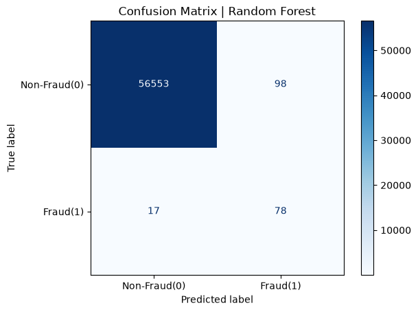

```
              precision    recall  f1-score   support

           0       1.00      1.00      1.00     56651
           1       0.44      0.82      0.58        95

    accuracy                           1.00     56746
   macro avg       0.72      0.91      0.79     56746
weighted avg       1.00      1.00      1.00     56746
```

```python
cm = ConfusionMatrixDisplay(confusion_matrix(y_test,rf_pred), display_labels= ['Non-Fraud(0)','Fraud(1)'])
cm.plot(cmap = 'Blues')
plt.title('Confusion Matrix | Random Forest')
plt.show()

print(classification_report(y_test, rf_pred))
```

Random Forest Classifier is able to return a better f1 score(0.58) than Logistic Regression(0.10) on the test set.

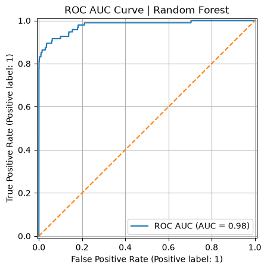

```python
rf_roc_auc = roc_auc_score(y_test, rf_prob)
RocCurveDisplay.from_estimator(
    estimator=rf_pipeline,
    X = X_test,
    y = y_test,
    name = 'ROC AUC'
)

plt.plot([0,1],[0,1],"--")
plt.title('ROC AUC Curve | Random Forest')
plt.grid()
plt.show()
```

A ROC AUC score of 0.98 means that if we randomly select one fraud and one non-fraud transaction, the model will correctly rank the fraud as higher risk than the non-fraud 98% of the time. However, this is an imbalanced dataset with a huge amount of True Negatives that drive the False Positive Rate down to tiny values, which makes the area under the ROC curve is massive (0.98). So ROC AUC score is not a good metric to evaluate the model performance in this case. Instead, we will also use Precision-Recall AUC (PR-AUC) to evaluate the model performance.

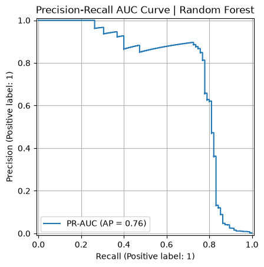

```python
rf_pr_auc = average_precision_score(y_test, rf_prob)
PrecisionRecallDisplay.from_estimator(
    estimator = rf_pipeline,
    X = X_test,
    y = y_test,
    name = "PR-AUC"
)

plt.title('Precision-Recall AUC Curve | Random Forest')
plt.grid()
plt.show()
```

The PR-AUC score of 0.76 means that if we average the precision across all recall levels, 76% of the transactions predicted as fraud are actually fraudulent.

We see that the PR-AUC blue line stays relatively flat and high until Recall hits 0.8. After the 0.8 mark, the precision drops sharply, so we can tune the threshold to safely catch 80% of true positive.

### 6.2.3 Cross-Validated Threshold Selection

```python
skf = StratifiedKFold(n_splits=5, shuffle=True, random_state=42)

rf_y_prob_train = cross_val_predict(
    estimator= rf_pipeline,
    X = X_train,
    y = y_train,
    cv = skf,
    method = 'predict_proba'
)[:,1]

rf_precision, rf_recall, rf_thresholds = precision_recall_curve(y_train, rf_y_prob_train)

rf_f1_scores = 2*(rf_precision*rf_recall)/(rf_precision + rf_recall + 1e-10)

rf_thresholds_df = pd.DataFrame({
    'threshold': rf_thresholds,
    'precision':rf_precision[:-1],
    'recall': rf_recall[:-1],
    'f1_score': rf_f1_scores[:-1]
})

rf_optimal_threshold = rf_thresholds_df.loc[rf_thresholds_df['f1_score'].idxmax(),'threshold']
print(f"RF optimal threshold: {rf_optimal_threshold:.8f}")
```

```
RF optimal threshold: 0.80079904
```

### 6.2.4 Test Evaluation for Tuned Threshold

```
              precision    recall  f1-score   support

           0       1.00      1.00      1.00     56651
           1       0.88      0.73      0.80        95

    accuracy                           1.00     56746
   macro avg       0.94      0.86      0.90     56746
weighted avg       1.00      1.00      1.00     56746
```

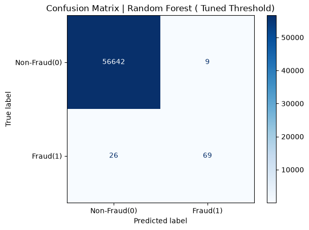

```python
rf_pred_tuned = (rf_prob >= rf_optimal_threshold).astype('int')
print(classification_report(y_test, rf_pred_tuned))
cm = ConfusionMatrixDisplay(confusion_matrix(y_test, rf_pred_tuned), display_labels=['Non-Fraud(0)','Fraud(1)'])
cm.plot(cmap = 'Blues')
plt.title('Confusion Matrix | Random Forest ( Tuned Threshold)')
plt.show()
```

```python
# Separate the model from pipeline
rf_model = rf_pipeline.named_steps['model']

importances = rf_model.feature_importances_

feature_names = rf_pipeline.named_steps['preprocessor'].get_feature_names_out()

importance_df = pd.DataFrame({
    'feature': feature_names,
    'importance': importances
}).sort_values(by = 'importance', ascending = False)

print(importance_df.head(15))
```

```
           feature  importance
15  remainder__V14    0.195844
11  remainder__V10    0.165029
13  remainder__V12    0.112226
5    remainder__V4    0.093945
12  remainder__V11    0.082756
18  remainder__V17    0.081348
4    remainder__V3    0.047408
17  remainder__V16    0.037034
3    remainder__V2    0.031798
8    remainder__V7    0.031682
10   remainder__V9    0.017241
22  remainder__V21    0.011576
9    remainder__V8    0.010659
6    remainder__V5    0.009986
2    remainder__V1    0.009769
```

the top Random Forest Classifier features importance are `V14`, `V12`, `V10`, `V17`, `V4`, which is consistent with the EDA finding in Section 2.3 and Logistic Regression feature importance analysis in Section 6.1.5.

### 6.2.5 Hyperparameter Tuning

We can perform hyperparameter tuning to find the best combination of hyperparameters for the Random Forest model, by using GridSearchCV to search through a predefined set of hyperparameters and evaluate the model performance using cross-validation. However, due to computational constraints, we will not perform it in this notebook.

```
from sklearn.model_selection import GridSearchCV

param_grid = {
    'model__n_estimators' :[200,300,400],
    'model__max_depth': [None, 8, 15],
    'model__min_samples_split': [2,4,6]
}

rf_grid_search = GridSearchCV(
    estimator = rf_pipeline,
    param_grid = param_grid,
    cv = 5,
    scoring = 'average_precision',
    n_jobs = -1, # Uses all CPU cores,
    verbose = 2 # print live progress updates to the consoles
)

rf_grid_search.fit(X_train, y_train)
```

### 6.2.6 Section Conclusion | Random Forest Classifier

Same as the Logistic Regression pipeline, we built a Random Forest Classifier pipeline with `RobustScaler` (for `Time`/`Amount`) and `SMOTE` inside an `imblearn.pipeline.Pipeline`.

**Key findings:**

**Conclusion:** Random Forest is a better ranker than Logistic Regression, but it does not beat Logistic Regression on tuned F1, precision, or recall, and it costs more under the current assumption.

## 6.3 XGBoost Classifier

XGBoost is a gradient boosting algorithm that is known for its high performance and efficiency. It builds an ensemble of decision trees in a sequential manner, where each tree tries to correct the errors of the previous one. This makes it particularly effective for imbalanced datasets like fraud detection.

Instead of using SMOTE, we will also use the `scale_pos_weight` parameter in XGBoost to handle class imbalance to see if it can achieve better performance than SMOTE. This parameter adjusts the weight of the positive class (fraud) during training, allowing the model to focus more on correctly classifying fraudulent transactions.

### 6.3.1 Training XGBoost Classifier Model

```python
import xgboost as xgb
from sklearn.pipeline import Pipeline
class_count = y_train.value_counts()
weight_ratio = class_count[0]/class_count[1]
xgb_spw_pipeline = Pipeline([
    (
        'preprocessor',
        preprocessor
    ),
    (
        'model',
        xgb.XGBClassifier(
            scale_pos_weight = weight_ratio,
            eval_metric = 'aucpr',
            n_estimators =200,
            max_depth = 5,
            random_state=42
        )
    )
])

xgb_spw_pipeline.fit(X_train, y_train)
xgb_spw_pred = xgb_spw_pipeline.predict(X_test)
xgb_spw_prob = xgb_spw_pipeline.predict_proba(X_test)[:,1]

xgb_smote_pipeline = ImbPipeline([
    (
        'preprocessor',
        preprocessor
    ),
    (
        'smote',
        SMOTE(random_state =42)
    ),
    (
        'model',
        xgb.XGBClassifier(
            n_estimators = 200,
            max_depth = 5,
            random_state = 42
        )
    )
])

xgb_smote_pipeline.fit(X_train, y_train)
xgb_smote_pred = xgb_smote_pipeline.predict(X_test)
xgb_smote_prob = xgb_smote_pipeline.predict_proba(X_test)[:,1]
```

### 6.3.2 Model Evaluation Metrics

```
              precision    recall  f1-score   support

           0       1.00      1.00      1.00     56651
           1       0.94      0.78      0.85        95

    accuracy                           1.00     56746
   macro avg       0.97      0.89      0.93     56746
weighted avg       1.00      1.00      1.00     56746
```

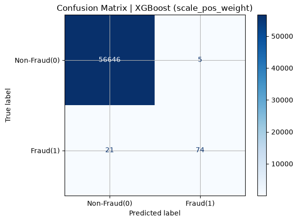

```python
print(classification_report(y_test, xgb_spw_pred))
cm = ConfusionMatrixDisplay(confusion_matrix(y_test, xgb_spw_pred), display_labels= ['Non-Fraud(0)', 'Fraud(1)'])
cm.plot(cmap='Blues')
plt.title('Confusion Matrix | XGBoost (scale_pos_weight)')
plt.grid()
plt.show()
```

```
              precision    recall  f1-score   support

           0       1.00      1.00      1.00     56651
           1       0.79      0.79      0.79        95

    accuracy                           1.00     56746
   macro avg       0.89      0.89      0.89     56746
weighted avg       1.00      1.00      1.00     56746
```

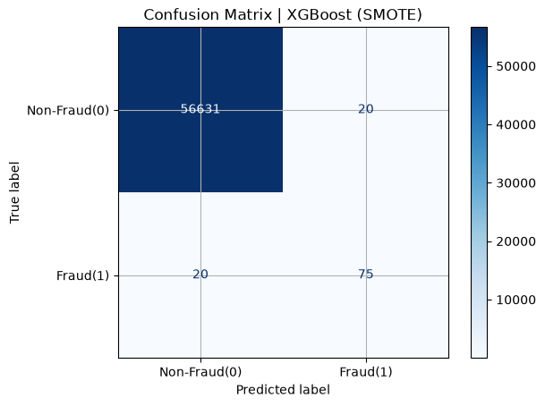

```python
print(classification_report(y_test, xgb_smote_pred))
cm = ConfusionMatrixDisplay(confusion_matrix(y_test, xgb_smote_pred), display_labels= ['Non-Fraud(0)', 'Fraud(1)'])
cm.plot(cmap='Blues')
plt.title('Confusion Matrix | XGBoost (SMOTE)')
plt.grid()
plt.show()
```

Both SMOTE and `scale_pos_weight` returns better results than the default 0.5 threshold than Logistic Regression's default result (precision 0.05, recall 0.87, F1 0.10 in 6.1).

However, 'scale_pos_weight' returns better results than SMOTE because it reweights the loss function during training rather than duplicating/synthesizing minority samples the way SMOTE does. This doesn't push predicted probabilities toward the extremes the way SMOTE does.

```
ROC-AUC: 0.9778
```

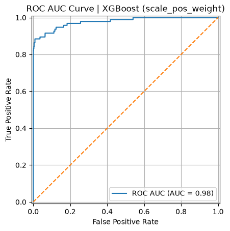

```python
xgb_roc_auc = roc_auc_score(y_test, xgb_spw_prob)
print(f'ROC-AUC: {xgb_roc_auc:.4f}')

RocCurveDisplay.from_estimator(
    estimator = xgb_spw_pipeline,
    X = X_test,
    y = y_test,
    name = 'ROC AUC'
)
plt.plot([0,1],[0,1],'--')
plt.title('ROC AUC Curve | XGBoost (scale_pos_weight)')
plt.xlabel('False Positive Rate')
plt.ylabel('True Positive Rate')
plt.grid()
plt.show()
```

```
ROC-AUC: 0.9672
```

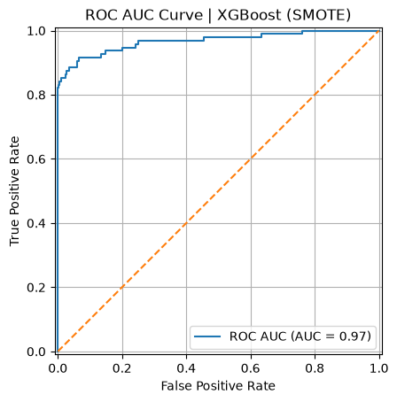

```python
xgb_smote_roc_auc = roc_auc_score(y_test, xgb_smote_prob)
print(f'ROC-AUC: {xgb_smote_roc_auc:.4f}')

RocCurveDisplay.from_estimator(
    estimator = xgb_smote_pipeline,
    X = X_test,
    y = y_test,
    name = 'ROC AUC'
)
plt.plot([0,1],[0,1],'--')
plt.title('ROC AUC Curve | XGBoost (SMOTE)')
plt.xlabel('False Positive Rate')
plt.ylabel('True Positive Rate')
plt.grid()
plt.show()
```

```
PR-AUC: 0.8163
```

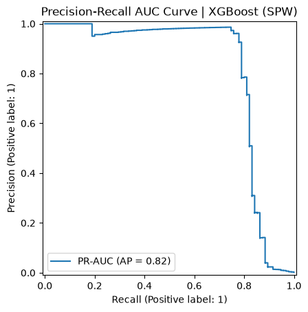

```python
xgb_pr_auc = average_precision_score(y_test, xgb_spw_prob)
print(f'PR-AUC: {xgb_pr_auc:.4f}')

PrecisionRecallDisplay.from_estimator(
    estimator = xgb_spw_pipeline,
    X = X_test,
    y = y_test,
    name = "PR-AUC"
)
plt.title('Precision-Recall AUC Curve | XGBoost (SPW)')
plt.show()
```

```
PR-AUC: 0.8130
```

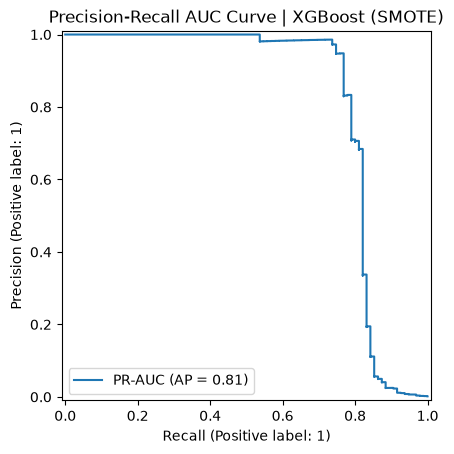

```python
xgb_smote_pr_auc = average_precision_score(y_test, xgb_smote_prob)
print(f'PR-AUC: {xgb_smote_pr_auc:.4f}')

PrecisionRecallDisplay.from_estimator(
    estimator = xgb_smote_pipeline,
    X = X_test,
    y = y_test,
    name = "PR-AUC"
)
plt.title('Precision-Recall AUC Curve | XGBoost (SMOTE)')
plt.show()
```

- **PR-AU('scale_pos_weight') ≈ 0.816**: the best of all three models so far (LR: 0.682, RF: 0.76). This is a meaningful gap, suggesting XGBoost's precision/recall tradeoff is genuinely more favorable across thresholds, not just at the one default cutoff.

**Analysis — XGBoost: `scale_pos_weight` vs. SMOTE:**

|  | scale_pos_weight | SMOTE |
| --- | --- | --- |
| Precision (fraud) | **0.94** | 0.79 |
| Recall (fraud) | 0.78 | 0.79 |
| F1 (fraud) | **0.85** | 0.79 |
| ROC-AUC | **0.978** | 0.967 |
| PR-AUC | **0.816** | 0.813 |

`scale_pos_weight` clearly wins here — noticeably higher precision and F1 at the default threshold, and modestly better on both AUC metrics, while recall is essentially tied. This confirms the 6.3 intro's suspicion was worth testing, and answers it directly: for XGBoost on this dataset, **reweighting the loss function is a better imbalance strategy than SMOTE oversampling.** A plausible explanation is that `scale_pos_weight` reweights the loss without changing the training distribution, while SMOTE changes it; we did not verify this calibration effect directly here.

**Decision: the rest of this section (threshold tuning, feature importance, final evaluation) proceeds with the `scale_pos_weight` pipeline (`xgb_spw_pipeline`)** as the better-performing variant; the SMOTE version is kept above only as the comparison evidence for this decision, not carried forward further.

### 6.3.3 Threshold Tuning

```python
skf = StratifiedKFold(
    n_splits = 5,
    shuffle = True,
    random_state= 42
)

xgb_train_proba = cross_val_predict(
    estimator = xgb_spw_pipeline,
    X = X_train,
    y = y_train,
    cv = skf,
    method = 'predict_proba'
)[:,1]

xgb_precision, xgb_recall, xgb_threshold = precision_recall_curve(y_train, xgb_train_proba)

xgb_f1_scores = 2*(xgb_precision*xgb_recall)/(xgb_precision + xgb_recall + 1e-10)

xgb_threshold_df = pd.DataFrame({
    'threshold': xgb_threshold,
    'precision': xgb_precision[:-1],
    'recall': xgb_recall[:-1],
    'f1_score': xgb_f1_scores[:-1]
}).sort_values(by = 'f1_score', ascending = False)

xgb_optimal_threshold = xgb_threshold_df.loc[xgb_threshold_df['f1_score'].idxmax(),'threshold']
xgb_optimal_threshold
```

```
np.float32(0.85101396)
```

```python
xgb_tuned_pred = (xgb_spw_prob >= xgb_optimal_threshold).astype(int)
```

```
              precision    recall  f1-score   support

           0       1.00      1.00      1.00     56651
           1       0.96      0.76      0.85        95

    accuracy                           1.00     56746
   macro avg       0.98      0.88      0.92     56746
weighted avg       1.00      1.00      1.00     56746
```

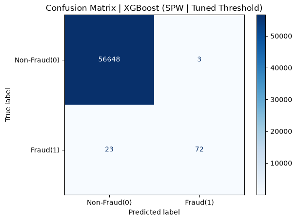

```python
print(classification_report(y_test, xgb_tuned_pred))
cm = ConfusionMatrixDisplay(confusion_matrix(y_test, xgb_tuned_pred), display_labels = ['Non-Fraud(0)','Fraud(1)'])
cm.plot(cmap='Blues')
plt.title('Confusion Matrix | XGBoost (SPW | Tuned Threshold)')
plt.show()
```

```python
skf = StratifiedKFold(
    n_splits = 5,
    shuffle = True,
    random_state= 42
)

xgb_smote_train_proba = cross_val_predict(
    estimator = xgb_smote_pipeline,
    X = X_train,
    y = y_train,
    cv = skf,
    method = 'predict_proba'
)[:,1]

xgb_smote_precision, xgb_smote_recall, xgb_smote_threshold = precision_recall_curve(y_train, xgb_smote_train_proba)

xgb_smote_f1_scores = 2*(xgb_smote_precision*xgb_smote_recall)/(xgb_smote_precision + xgb_smote_recall + 1e-10)

xgb_smote_threshold_df = pd.DataFrame({
    'smote_threshold': xgb_smote_threshold,
    'smote_precision': xgb_smote_precision[:-1],
    'smote_recall': xgb_smote_recall[:-1],
    'smote_f1_score': xgb_smote_f1_scores[:-1]
}).sort_values(by = 'smote_f1_score', ascending = False)

xgb_smote_optimal_threshold = xgb_smote_threshold_df.loc[xgb_smote_threshold_df['smote_f1_score'].idxmax(),'smote_threshold']
xgb_smote_optimal_threshold
```

```
np.float32(0.97749215)
```

```python
xgb_smote_tuned_pred = (xgb_smote_prob >= xgb_smote_optimal_threshold).astype(int)
```

```
              precision    recall  f1-score   support

           0       1.00      1.00      1.00     56651
           1       0.96      0.75      0.84        95

    accuracy                           1.00     56746
   macro avg       0.98      0.87      0.92     56746
weighted avg       1.00      1.00      1.00     56746
```

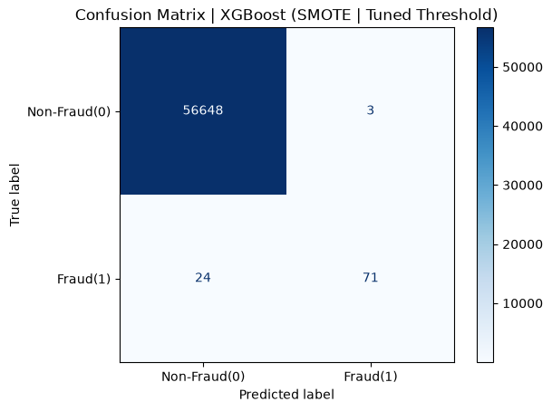

```python
print(classification_report(y_test, xgb_smote_tuned_pred))
cm = ConfusionMatrixDisplay(confusion_matrix(y_test, xgb_smote_tuned_pred), display_labels = ['Non-Fraud(0)','Fraud(1)'])
cm.plot(cmap='Blues')
plt.title('Confusion Matrix | XGBoost (SMOTE | Tuned Threshold)')
plt.show()
```

Unlike Logistic Regression, where cross-validated threshold tuning was the single biggest lever (F1 0.10 → 0.80), **tuning barely moves XGBoost's result at all** for `scale_pos_weight` method, but it does a little for SMOTE with F1 0.79 → 0.84

A likely explanation is that using `scale_pos_weight` instead of SMOTE leaves the default threshold already close to optimal, so there is little room for threshold tuning to improve on it.

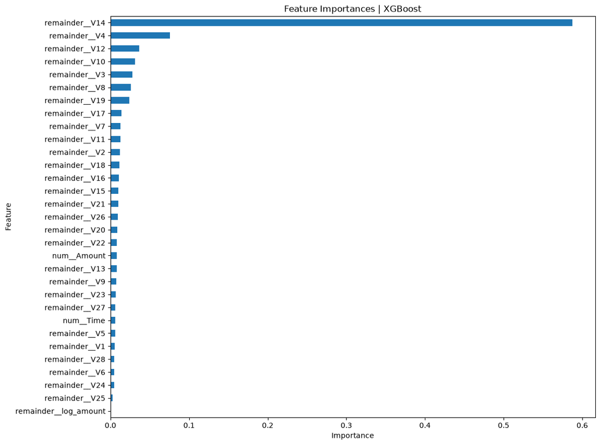

```python
xgb_importance = xgb_spw_pipeline.named_steps['model'].feature_importances_
xgb_feature_names = xgb_spw_pipeline.named_steps['preprocessor'].get_feature_names_out()
xgb_importance_df = pd.DataFrame({
    'feature': xgb_feature_names,
    'importance': xgb_importance
}).sort_values(by='importance', ascending=True)
xgb_importance_df.plot(kind='barh', x='feature', y='importance', figsize=(12,10), legend=False)
plt.title('Feature Importances | XGBoost')
plt.xlabel('Importance')
plt.ylabel('Feature')
plt.show()
```

### 6.3.4 Section Conclusion | XGBoost Classifier

We built an XGBoost pipeline with `RobustScaler` (for `Time`/`Amount`) and `scale_pos_weight` set to the class ratio, and compared it with a SMOTE variant.

**Key findings:**

## 6.4 Model Comparison

```python
model_comparision_df = pd.DataFrame({
    'Model': ['XGBoost','Random Forest','Logistic Regression'],
    'ROC-AUC': [xgb_roc_auc, rf_roc_auc, lr_roc_auc],
    'PR-AUC': [xgb_pr_auc, rf_pr_auc, lr_pr_auc]
})

for name, y_pred in [
    ('XGBoost', xgb_tuned_pred),
    ('Logistic Regression', lr_pred_tuned),
    ('Random Forest', rf_pred_tuned)
]:
    report = classification_report(y_test, y_pred, output_dict= True)['1']
    model_comparision_df.loc[model_comparision_df['Model'] == name, 'Precision'] = report['precision']
    model_comparision_df.loc[model_comparision_df['Model'] == name, 'Recall'] = report['recall']
    model_comparision_df.loc[model_comparision_df['Model'] == name, 'F1 Score'] = report['f1-score']
    model_comparision_df.loc[model_comparision_df['Model'] == name, 'Total Cost'] = total_cost(y_test.values, y_pred, X_test['Amount'].values, review_cost = 12)

model_comparision_df.style.background_gradient(cmap='Blues')
```

|  | Model | ROC-AUC | PR-AUC | Precision | Recall | F1 Score | Total Cost |
| --- | --- | --- | --- | --- | --- | --- | --- |
| 0 | XGBoost | 0.977779 | 0.816294 | 0.960000 | 0.757895 | 0.847059 | 4087.530000 |
| 1 | Random Forest | 0.978155 | 0.758674 | 0.884615 | 0.726316 | 0.797688 | 5979.300000 |
| 2 | Logistic Regression | 0.957143 | 0.681576 | 0.887500 | 0.747368 | 0.811429 | 3920.280000 |

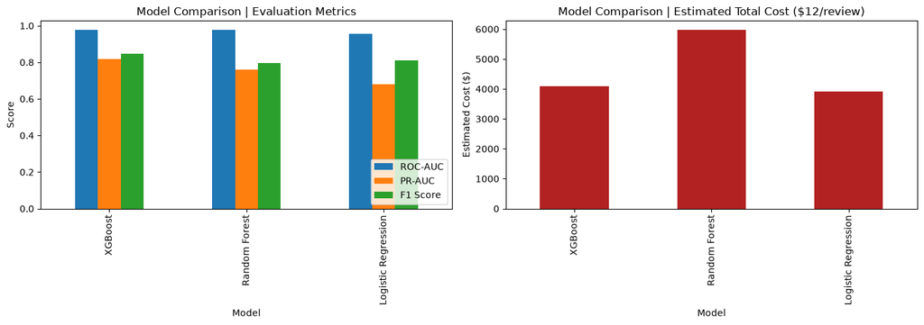

```python
fig, axes = plt.subplots(1, 2, figsize=(14, 5))

model_comparision_df.set_index('Model')[['ROC-AUC', 'PR-AUC', 'F1 Score']].plot(kind='bar', ax=axes[0])
axes[0].set_title('Model Comparison | Evaluation Metrics')
axes[0].set_ylabel('Score')
axes[0].legend(loc='lower right')

model_comparision_df.set_index('Model')['Total Cost'].plot(kind='bar', ax=axes[1], color='firebrick')
axes[1].set_title('Model Comparison | Estimated Total Cost ($12/review)')
axes[1].set_ylabel('Estimated Cost ($)')

plt.tight_layout()
plt.show()
```